# Convolution Assignment : Group 2

## Author : Dev and Sakshi Bansal

### "Deep learning for computer vision" - Classifying Images

Importing all the needed modules :

```python
import matplotlib.pyplot as plt
import os
import shutil as sl
import pathlib as pl
```

**We will be using "Dogs-vs-Cats" dataset for this project**

**Q-1 Consider the Cats & Dogs example. Start initially with a training sample of 1000, a validation sample of 500, and a test sample of 500 (like in the text). Use any technique to reduce overfitting and improve performance in developing a network that you train from scratch. What performance did you achieve?**

```python
# Defining directory of folder to store subsets of our originial data
small_directory = pl.Path("/Users/devmarwah/Desktop/dogs-vs-cats/small")
directory_path = pl.Path("/Users/devmarwah/Desktop/dogs-vs-cats/train")

# Defining a function to make subsets
def make_subset(subset_name,start_index,end_index):
    for category in ("cat","dog"):
        dir = small_directory/ subset_name / category
        os.makedirs(dir)
        fnames = [f"{category}.{i}.jpg"
                 for i in range(start_index,end_index)]
        for fname in fnames:
            sl.copyfile(src = directory_path/fname ,
                       dst = dir/fname)


make_subset("Training",start_index=0,end_index=1000)
make_subset("Validation",start_index = 1000, end_index = 1500)
make_subset("Test",start_index = 1500,end_index = 2000)
```

Reading training, validation and testing datsets

```python
from tensorflow.keras.utils import image_dataset_from_directory as id

Train = id("/Users/devmarwah/Desktop/dogs-vs-cats/Small/Training",image_size=(180,180),batch_size=32)
Validation = id("/Users/devmarwah/Desktop/dogs-vs-cats/Small/Validation",image_size=(180,180),batch_size=32)
Test = id("/Users/devmarwah/Desktop/dogs-vs-cats/Small/Test",image_size=(180,180),batch_size=32)
```

```
Found 2000 files belonging to 2 classes.
Found 1000 files belonging to 2 classes.
Found 1000 files belonging to 2 classes.
```

Printing shapes of our datsets to make sure we got everything right.

```python
for i,j in Train :
    print('Shape of Image : ', i.shape)
    print('Size of Batches :', j.shape)
    break
```

```
Shape of Image :  (32, 180, 180, 3)
Size of Batches : (32,)
```

Hence, our batch size in 32 and images are of shape (180,180,3) where 3 refers to RGB colored image.

### Constructing Model

```python
# Importing keras and layers
from tensorflow import keras
from tensorflow.keras import layers
```

Constructing the model :

```python
inputs = keras.Input(shape = (180,180,3))
x = layers.Rescaling(1./255)(inputs)
x = layers.Conv2D(filters = 32, kernel_size = 3, activation = "relu")(x)
x = layers.MaxPooling2D(pool_size=2)(x)
x = layers.Conv2D(filters = 64, kernel_size = 3, activation = "relu")(x)
x = layers.MaxPooling2D(pool_size=2)(x)
x = layers.Conv2D(filters = 128, kernel_size = 3, activation = "relu")(x)
x = layers.MaxPooling2D(pool_size=2)(x)
x = layers.Conv2D(filters = 256, kernel_size = 3, activation = "relu")(x)
x = layers.MaxPooling2D(pool_size=2)(x)
x = layers.Conv2D(filters = 256, kernel_size = 3, activation = "relu")(x)
x = layers.Flatten()(x)
outputs = layers.Dense(1,activation = "sigmoid")(x)
model = keras.Model(inputs = inputs, outputs = outputs)
```

Having a look at the model

```python
model.summary()
```

```
Model: "functional_1"
```

```
┏━━━━━━━━━━━━━━━━━━━━━━━━━━━━━━━━━┳━━━━━━━━━━━━━━━━━━━━━━━━┳━━━━━━━━━━━━━━━┓
┃ Layer (type)                    ┃ Output Shape           ┃       Param # ┃
┡━━━━━━━━━━━━━━━━━━━━━━━━━━━━━━━━━╇━━━━━━━━━━━━━━━━━━━━━━━━╇━━━━━━━━━━━━━━━┩
│ input_layer (InputLayer)        │ (None, 180, 180, 3)    │             0 │
├─────────────────────────────────┼────────────────────────┼───────────────┤
│ rescaling (Rescaling)           │ (None, 180, 180, 3)    │             0 │
├─────────────────────────────────┼────────────────────────┼───────────────┤
│ conv2d (Conv2D)                 │ (None, 178, 178, 32)   │           896 │
├─────────────────────────────────┼────────────────────────┼───────────────┤
│ max_pooling2d (MaxPooling2D)    │ (None, 89, 89, 32)     │             0 │
├─────────────────────────────────┼────────────────────────┼───────────────┤
│ conv2d_1 (Conv2D)               │ (None, 87, 87, 64)     │        18,496 │
├─────────────────────────────────┼────────────────────────┼───────────────┤
│ max_pooling2d_1 (MaxPooling2D)  │ (None, 43, 43, 64)     │             0 │
├─────────────────────────────────┼────────────────────────┼───────────────┤
│ conv2d_2 (Conv2D)               │ (None, 41, 41, 128)    │        73,856 │
├─────────────────────────────────┼────────────────────────┼───────────────┤
│ max_pooling2d_2 (MaxPooling2D)  │ (None, 20, 20, 128)    │             0 │
├─────────────────────────────────┼────────────────────────┼───────────────┤
│ conv2d_3 (Conv2D)               │ (None, 18, 18, 256)    │       295,168 │
├─────────────────────────────────┼────────────────────────┼───────────────┤
│ max_pooling2d_3 (MaxPooling2D)  │ (None, 9, 9, 256)      │             0 │
├─────────────────────────────────┼────────────────────────┼───────────────┤
│ conv2d_4 (Conv2D)               │ (None, 7, 7, 256)      │       590,080 │
├─────────────────────────────────┼────────────────────────┼───────────────┤
│ flatten (Flatten)               │ (None, 12544)          │             0 │
├─────────────────────────────────┼────────────────────────┼───────────────┤
│ dense (Dense)                   │ (None, 1)              │        12,545 │
└─────────────────────────────────┴────────────────────────┴───────────────┘
```

```
 Total params: 991,041 (3.78 MB)
```

```
 Trainable params: 991,041 (3.78 MB)
```

```
 Non-trainable params: 0 (0.00 B)
```

Compiling the constructed model

```python
model.compile(loss = "binary_crossentropy",
             optimizer= "Adam",
             metrics = ["accuracy"])
```

Fitting the model on training and validation set

```python
training = model.fit(Train,
                    epochs = 30,
                    validation_data = Validation)
```

```
63/63 ━━━━━━━━━━━━━━━━━━━━ 33s 521ms/step - accuracy: 0.4857 - loss: 0.7089 - val_accuracy: 0.5000 - val_loss: 0.6928
63/63 ━━━━━━━━━━━━━━━━━━━━ 35s 561ms/step - accuracy: 0.4998 - loss: 0.6925 - val_accuracy: 0.5350 - val_loss: 0.6853
63/63 ━━━━━━━━━━━━━━━━━━━━ 37s 592ms/step - accuracy: 0.5265 - loss: 0.6944 - val_accuracy: 0.5150 - val_loss: 0.6927
63/63 ━━━━━━━━━━━━━━━━━━━━ 38s 597ms/step - accuracy: 0.5251 - loss: 0.6910 - val_accuracy: 0.5170 - val_loss: 0.6897
63/63 ━━━━━━━━━━━━━━━━━━━━ 38s 599ms/step - accuracy: 0.5572 - loss: 0.6820 - val_accuracy: 0.5620 - val_loss: 0.6705
63/63 ━━━━━━━━━━━━━━━━━━━━ 38s 598ms/step - accuracy: 0.6012 - loss: 0.6565 - val_accuracy: 0.6550 - val_loss: 0.6334
63/63 ━━━━━━━━━━━━━━━━━━━━ 39s 614ms/step - accuracy: 0.6891 - loss: 0.5996 - val_accuracy: 0.6610 - val_loss: 0.6179
63/63 ━━━━━━━━━━━━━━━━━━━━ 40s 629ms/step - accuracy: 0.7104 - loss: 0.5740 - val_accuracy: 0.6800 - val_loss: 0.5870
63/63 ━━━━━━━━━━━━━━━━━━━━ 40s 640ms/step - accuracy: 0.7263 - loss: 0.5338 - val_accuracy: 0.7110 - val_loss: 0.5722
63/63 ━━━━━━━━━━━━━━━━━━━━ 40s 641ms/step - accuracy: 0.7801 - loss: 0.4713 - val_accuracy: 0.7150 - val_loss: 0.5697
63/63 ━━━━━━━━━━━━━━━━━━━━ 42s 660ms/step - accuracy: 0.7971 - loss: 0.4364 - val_accuracy: 0.7430 - val_loss: 0.5266
63/63 ━━━━━━━━━━━━━━━━━━━━ 42s 673ms/step - accuracy: 0.8415 - loss: 0.3533 - val_accuracy: 0.7550 - val_loss: 0.5628
63/63 ━━━━━━━━━━━━━━━━━━━━ 42s 669ms/step - accuracy: 0.8652 - loss: 0.3126 - val_accuracy: 0.7550 - val_loss: 0.5832
63/63 ━━━━━━━━━━━━━━━━━━━━ 42s 668ms/step - accuracy: 0.9108 - loss: 0.2197 - val_accuracy: 0.7390 - val_loss: 0.6994
63/63 ━━━━━━━━━━━━━━━━━━━━ 43s 674ms/step - accuracy: 0.9336 - loss: 0.1692 - val_accuracy: 0.7430 - val_loss: 0.8998
63/63 ━━━━━━━━━━━━━━━━━━━━ 43s 681ms/step - accuracy: 0.9634 - loss: 0.1025 - val_accuracy: 0.7450 - val_loss: 0.8992
63/63 ━━━━━━━━━━━━━━━━━━━━ 43s 681ms/step - accuracy: 0.9717 - loss: 0.0752 - val_accuracy: 0.7280 - val_loss: 1.0905
63/63 ━━━━━━━━━━━━━━━━━━━━ 43s 682ms/step - accuracy: 0.9659 - loss: 0.0825 - val_accuracy: 0.7460 - val_loss: 1.0894
63/63 ━━━━━━━━━━━━━━━━━━━━ 43s 680ms/step - accuracy: 0.9878 - loss: 0.0353 - val_accuracy: 0.7450 - val_loss: 1.3058
63/63 ━━━━━━━━━━━━━━━━━━━━ 41s 644ms/step - accuracy: 0.9867 - loss: 0.0425 - val_accuracy: 0.7300 - val_loss: 1.1509
63/63 ━━━━━━━━━━━━━━━━━━━━ 39s 618ms/step - accuracy: 0.9904 - loss: 0.0341 - val_accuracy: 0.7340 - val_loss: 1.2492
63/63 ━━━━━━━━━━━━━━━━━━━━ 40s 630ms/step - accuracy: 0.9914 - loss: 0.0233 - val_accuracy: 0.7310 - val_loss: 1.3370
63/63 ━━━━━━━━━━━━━━━━━━━━ 39s 625ms/step - accuracy: 0.9952 - loss: 0.0178 - val_accuracy: 0.7260 - val_loss: 1.5562
63/63 ━━━━━━━━━━━━━━━━━━━━ 39s 626ms/step - accuracy: 0.9909 - loss: 0.0315 - val_accuracy: 0.7160 - val_loss: 1.5779
63/63 ━━━━━━━━━━━━━━━━━━━━ 40s 634ms/step - accuracy: 0.9867 - loss: 0.0395 - val_accuracy: 0.7210 - val_loss: 1.5001
63/63 ━━━━━━━━━━━━━━━━━━━━ 40s 638ms/step - accuracy: 0.9899 - loss: 0.0377 - val_accuracy: 0.7510 - val_loss: 1.7554
63/63 ━━━━━━━━━━━━━━━━━━━━ 40s 642ms/step - accuracy: 0.9870 - loss: 0.0308 - val_accuracy: 0.7440 - val_loss: 1.4723
63/63 ━━━━━━━━━━━━━━━━━━━━ 40s 639ms/step - accuracy: 0.9975 - loss: 0.0095 - val_accuracy: 0.7450 - val_loss: 1.5563
63/63 ━━━━━━━━━━━━━━━━━━━━ 41s 645ms/step - accuracy: 1.0000 - loss: 0.0010 - val_accuracy: 0.7440 - val_loss: 1.6456
63/63 ━━━━━━━━━━━━━━━━━━━━ 41s 651ms/step - accuracy: 1.0000 - loss: 4.2587e-04 - val_accuracy: 0.7530 - val_loss: 1.7556
```

Now, we will be plotting loss and accuracy of training and validation set to check for overfitting.b

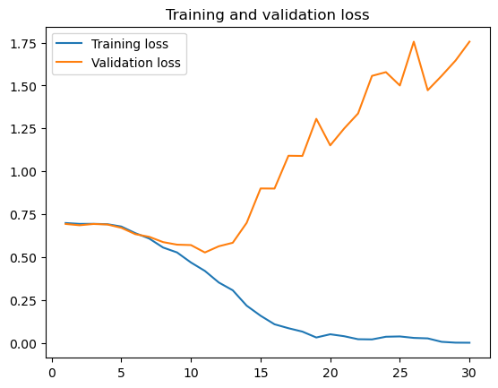

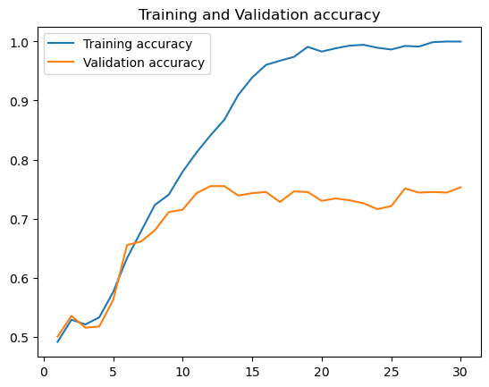

```python
# Storing accuracies and losses in variables
accuracy = training.history["accuracy"]
val_accuracy = training.history["val_accuracy"]
loss = training.history["loss"]
val_loss = training.history["val_loss"]
epochs = range(1,len(accuracy)+1)
# Plotting losses
plt.plot(epochs,loss,label="Training loss")
plt.plot(epochs,val_loss,label="Validation loss")
plt.title("Training and validation loss")
plt.legend()
plt.figure()
# Plotting accuracies
plt.plot(epochs,accuracy,label="Training accuracy")
plt.plot(epochs, val_accuracy,label="Validation accuracy")
plt.title("Training and Validation accuracy")
plt.legend()
```

These graphs are characteristics of **overfitting**. We would have apply some techniques to overcome overfitting. Let's check accuracy on testing data. It is expected to be low because of overfitting.

```python
model.evaluate(Test)
```

```
32/32 ━━━━━━━━━━━━━━━━━━━━ 5s 169ms/step - accuracy: 0.7559 - loss: 1.7108
```

```
[1.8736166954040527, 0.746999979019165]
```

Hence, accuracy turned out to be 75.6 % which is a very low accuracy.

### Using data augmentation and dropout to reduce overfitting

```python
# Using keras sequential for data augmentation
data_augmentation = keras.Sequential(
[
    layers.RandomFlip("horizontal"),
    layers.RandomRotation(0.1),
    layers.RandomZoom(0.1)
])
```

Trying to print photos to have a look at data augmentation:

```
2024-03-31 18:54:38.438140: W tensorflow/core/framework/local_rendezvous.cc:404] Local rendezvous is aborting with status: OUT_OF_RANGE: End of sequence
```

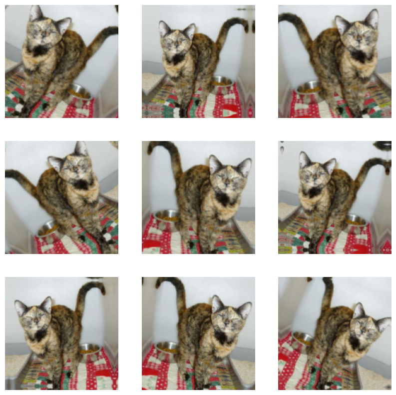

```python
import numpy
plt.figure(figsize=(10, 10))
for images, labels  in Train.take(1):
    for i in range(9):
        augmented_images = data_augmentation(images)
        ax = plt.subplot(3, 3, i + 1)
        plt.imshow(augmented_images[0].numpy().astype("uint8"))
        plt.axis("off")
```

Constructing model again with Data Augmentation and Dropout :

```python
inputs = keras.Input(shape = (180,180,3))
x=data_augmentation(inputs)
x = layers.Rescaling(1./255)(x)
x = layers.Conv2D(filters = 32, kernel_size = 3, activation = "relu")(x)
x = layers.MaxPooling2D(pool_size=2)(x)
x = layers.Conv2D(filters = 64, kernel_size = 3, activation = "relu")(x)
x = layers.MaxPooling2D(pool_size=2)(x)
x = layers.Conv2D(filters = 128, kernel_size = 3, activation = "relu")(x)
x = layers.MaxPooling2D(pool_size=2)(x)
x = layers.Conv2D(filters = 256, kernel_size = 3, activation = "relu")(x)
x = layers.MaxPooling2D(pool_size=2)(x)
x = layers.Conv2D(filters = 256, kernel_size = 3, activation = "relu")(x)
x = layers.Flatten()(x)
x= layers.Dropout(0.5)(x)
outputs = layers.Dense(1,activation = "sigmoid")(x)
model = keras.Model(inputs = inputs, outputs = outputs)

# Compiling model
model.compile(loss = "binary_crossentropy",
             optimizer= "Adam",
             metrics = ["accuracy"])
model.summary()
```

```
Model: "functional_3"
```

```
┏━━━━━━━━━━━━━━━━━━━━━━━━━━━━━━━━━┳━━━━━━━━━━━━━━━━━━━━━━━━┳━━━━━━━━━━━━━━━┓
┃ Layer (type)                    ┃ Output Shape           ┃       Param # ┃
┡━━━━━━━━━━━━━━━━━━━━━━━━━━━━━━━━━╇━━━━━━━━━━━━━━━━━━━━━━━━╇━━━━━━━━━━━━━━━┩
│ input_layer_1 (InputLayer)      │ (None, 180, 180, 3)    │             0 │
├─────────────────────────────────┼────────────────────────┼───────────────┤
│ sequential (Sequential)         │ (None, 180, 180, 3)    │             0 │
├─────────────────────────────────┼────────────────────────┼───────────────┤
│ rescaling_1 (Rescaling)         │ (None, 180, 180, 3)    │             0 │
├─────────────────────────────────┼────────────────────────┼───────────────┤
│ conv2d_5 (Conv2D)               │ (None, 178, 178, 32)   │           896 │
├─────────────────────────────────┼────────────────────────┼───────────────┤
│ max_pooling2d_4 (MaxPooling2D)  │ (None, 89, 89, 32)     │             0 │
├─────────────────────────────────┼────────────────────────┼───────────────┤
│ conv2d_6 (Conv2D)               │ (None, 87, 87, 64)     │        18,496 │
├─────────────────────────────────┼────────────────────────┼───────────────┤
│ max_pooling2d_5 (MaxPooling2D)  │ (None, 43, 43, 64)     │             0 │
├─────────────────────────────────┼────────────────────────┼───────────────┤
│ conv2d_7 (Conv2D)               │ (None, 41, 41, 128)    │        73,856 │
├─────────────────────────────────┼────────────────────────┼───────────────┤
│ max_pooling2d_6 (MaxPooling2D)  │ (None, 20, 20, 128)    │             0 │
├─────────────────────────────────┼────────────────────────┼───────────────┤
│ conv2d_8 (Conv2D)               │ (None, 18, 18, 256)    │       295,168 │
├─────────────────────────────────┼────────────────────────┼───────────────┤
│ max_pooling2d_7 (MaxPooling2D)  │ (None, 9, 9, 256)      │             0 │
├─────────────────────────────────┼────────────────────────┼───────────────┤
│ conv2d_9 (Conv2D)               │ (None, 7, 7, 256)      │       590,080 │
├─────────────────────────────────┼────────────────────────┼───────────────┤
│ flatten_1 (Flatten)             │ (None, 12544)          │             0 │
├─────────────────────────────────┼────────────────────────┼───────────────┤
│ dropout (Dropout)               │ (None, 12544)          │             0 │
├─────────────────────────────────┼────────────────────────┼───────────────┤
│ dense_1 (Dense)                 │ (None, 1)              │        12,545 │
└─────────────────────────────────┴────────────────────────┴───────────────┘
```

```
 Total params: 991,041 (3.78 MB)
```

```
 Trainable params: 991,041 (3.78 MB)
```

```
 Non-trainable params: 0 (0.00 B)
```

```python
# Fitting this new model :
training = model.fit(Train,
                    epochs = 60,
                    validation_data = Validation)
```

```
63/63 ━━━━━━━━━━━━━━━━━━━━ 30s 472ms/step - accuracy: 0.5837 - loss: 0.6865 - val_accuracy: 0.5630 - val_loss: 0.6698
63/63 ━━━━━━━━━━━━━━━━━━━━ 31s 500ms/step - accuracy: 0.6227 - loss: 0.6531 - val_accuracy: 0.6310 - val_loss: 0.6431
63/63 ━━━━━━━━━━━━━━━━━━━━ 33s 523ms/step - accuracy: 0.6417 - loss: 0.6446 - val_accuracy: 0.5960 - val_loss: 0.6529
63/63 ━━━━━━━━━━━━━━━━━━━━ 34s 536ms/step - accuracy: 0.6706 - loss: 0.6118 - val_accuracy: 0.6530 - val_loss: 0.6160
63/63 ━━━━━━━━━━━━━━━━━━━━ 35s 563ms/step - accuracy: 0.7102 - loss: 0.5703 - val_accuracy: 0.7100 - val_loss: 0.5608
63/63 ━━━━━━━━━━━━━━━━━━━━ 37s 582ms/step - accuracy: 0.6862 - loss: 0.6055 - val_accuracy: 0.6530 - val_loss: 0.6072
63/63 ━━━━━━━━━━━━━━━━━━━━ 36s 566ms/step - accuracy: 0.6827 - loss: 0.5930 - val_accuracy: 0.6990 - val_loss: 0.5760
63/63 ━━━━━━━━━━━━━━━━━━━━ 37s 582ms/step - accuracy: 0.7157 - loss: 0.5564 - val_accuracy: 0.6510 - val_loss: 0.6043
63/63 ━━━━━━━━━━━━━━━━━━━━ 36s 576ms/step - accuracy: 0.6879 - loss: 0.5906 - val_accuracy: 0.7110 - val_loss: 0.5728
63/63 ━━━━━━━━━━━━━━━━━━━━ 39s 622ms/step - accuracy: 0.7354 - loss: 0.5427 - val_accuracy: 0.6170 - val_loss: 0.6217
63/63 ━━━━━━━━━━━━━━━━━━━━ 38s 603ms/step - accuracy: 0.7056 - loss: 0.5515 - val_accuracy: 0.7320 - val_loss: 0.5225
63/63 ━━━━━━━━━━━━━━━━━━━━ 39s 614ms/step - accuracy: 0.7561 - loss: 0.4950 - val_accuracy: 0.7430 - val_loss: 0.5081
63/63 ━━━━━━━━━━━━━━━━━━━━ 39s 621ms/step - accuracy: 0.7680 - loss: 0.4836 - val_accuracy: 0.7550 - val_loss: 0.4929
63/63 ━━━━━━━━━━━━━━━━━━━━ 39s 621ms/step - accuracy: 0.7430 - loss: 0.5017 - val_accuracy: 0.7600 - val_loss: 0.5045
63/63 ━━━━━━━━━━━━━━━━━━━━ 41s 647ms/step - accuracy: 0.7624 - loss: 0.4934 - val_accuracy: 0.7730 - val_loss: 0.4695
63/63 ━━━━━━━━━━━━━━━━━━━━ 39s 624ms/step - accuracy: 0.7834 - loss: 0.4509 - val_accuracy: 0.7460 - val_loss: 0.4910
63/63 ━━━━━━━━━━━━━━━━━━━━ 40s 632ms/step - accuracy: 0.7778 - loss: 0.4656 - val_accuracy: 0.7650 - val_loss: 0.4747
63/63 ━━━━━━━━━━━━━━━━━━━━ 38s 595ms/step - accuracy: 0.7796 - loss: 0.4517 - val_accuracy: 0.7820 - val_loss: 0.4706
63/63 ━━━━━━━━━━━━━━━━━━━━ 39s 615ms/step - accuracy: 0.7951 - loss: 0.4447 - val_accuracy: 0.8010 - val_loss: 0.4431
63/63 ━━━━━━━━━━━━━━━━━━━━ 38s 608ms/step - accuracy: 0.8118 - loss: 0.4193 - val_accuracy: 0.8000 - val_loss: 0.4613
63/63 ━━━━━━━━━━━━━━━━━━━━ 37s 590ms/step - accuracy: 0.7819 - loss: 0.4644 - val_accuracy: 0.8090 - val_loss: 0.4294
63/63 ━━━━━━━━━━━━━━━━━━━━ 38s 596ms/step - accuracy: 0.8173 - loss: 0.4014 - val_accuracy: 0.7770 - val_loss: 0.4692
63/63 ━━━━━━━━━━━━━━━━━━━━ 38s 598ms/step - accuracy: 0.7949 - loss: 0.4443 - val_accuracy: 0.8000 - val_loss: 0.4374
63/63 ━━━━━━━━━━━━━━━━━━━━ 37s 592ms/step - accuracy: 0.7926 - loss: 0.4377 - val_accuracy: 0.7660 - val_loss: 0.4663
63/63 ━━━━━━━━━━━━━━━━━━━━ 37s 594ms/step - accuracy: 0.8382 - loss: 0.3600 - val_accuracy: 0.7960 - val_loss: 0.4354
63/63 ━━━━━━━━━━━━━━━━━━━━ 37s 592ms/step - accuracy: 0.8111 - loss: 0.4241 - val_accuracy: 0.8120 - val_loss: 0.4272
63/63 ━━━━━━━━━━━━━━━━━━━━ 38s 600ms/step - accuracy: 0.8489 - loss: 0.3549 - val_accuracy: 0.7910 - val_loss: 0.4617
63/63 ━━━━━━━━━━━━━━━━━━━━ 38s 604ms/step - accuracy: 0.8331 - loss: 0.3782 - val_accuracy: 0.8170 - val_loss: 0.4071
63/63 ━━━━━━━━━━━━━━━━━━━━ 37s 592ms/step - accuracy: 0.8397 - loss: 0.3555 - val_accuracy: 0.7740 - val_loss: 0.4676
63/63 ━━━━━━━━━━━━━━━━━━━━ 37s 593ms/step - accuracy: 0.8250 - loss: 0.3881 - val_accuracy: 0.7990 - val_loss: 0.4347
63/63 ━━━━━━━━━━━━━━━━━━━━ 39s 625ms/step - accuracy: 0.8386 - loss: 0.3422 - val_accuracy: 0.8190 - val_loss: 0.4295
63/63 ━━━━━━━━━━━━━━━━━━━━ 39s 613ms/step - accuracy: 0.8449 - loss: 0.3423 - val_accuracy: 0.8140 - val_loss: 0.4146
63/63 ━━━━━━━━━━━━━━━━━━━━ 39s 621ms/step - accuracy: 0.8485 - loss: 0.3457 - val_accuracy: 0.8160 - val_loss: 0.4256
63/63 ━━━━━━━━━━━━━━━━━━━━ 38s 603ms/step - accuracy: 0.8572 - loss: 0.3307 - val_accuracy: 0.8010 - val_loss: 0.4740
63/63 ━━━━━━━━━━━━━━━━━━━━ 38s 606ms/step - accuracy: 0.8488 - loss: 0.3363 - val_accuracy: 0.8170 - val_loss: 0.4516
63/63 ━━━━━━━━━━━━━━━━━━━━ 39s 611ms/step - accuracy: 0.8700 - loss: 0.2946 - val_accuracy: 0.8310 - val_loss: 0.3865
63/63 ━━━━━━━━━━━━━━━━━━━━ 38s 608ms/step - accuracy: 0.8789 - loss: 0.3002 - val_accuracy: 0.8300 - val_loss: 0.4098
63/63 ━━━━━━━━━━━━━━━━━━━━ 38s 599ms/step - accuracy: 0.8746 - loss: 0.2900 - val_accuracy: 0.8160 - val_loss: 0.4252
63/63 ━━━━━━━━━━━━━━━━━━━━ 39s 613ms/step - accuracy: 0.8701 - loss: 0.2919 - val_accuracy: 0.8280 - val_loss: 0.3979
63/63 ━━━━━━━━━━━━━━━━━━━━ 37s 592ms/step - accuracy: 0.8823 - loss: 0.2738 - val_accuracy: 0.8180 - val_loss: 0.4366
```

[output cut: 20 more lines]

Plotting accuracies and losses :

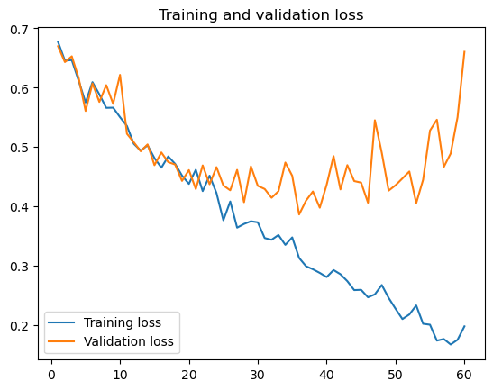

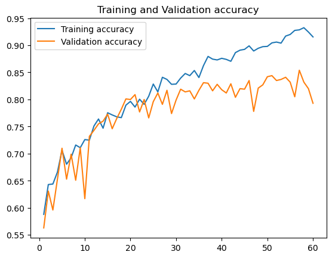

```python
# Storing accuracies and losses in variables
accuracy = training.history["accuracy"]
val_accuracy = training.history["val_accuracy"]
loss = training.history["loss"]
val_loss = training.history["val_loss"]
epochs = range(1,len(accuracy)+1)
# Plotting losses
plt.plot(epochs,loss,label="Training loss")
plt.plot(epochs,val_loss,label="Validation loss")
plt.title("Training and validation loss")
plt.legend()
plt.figure()
# Plotting accuracies
plt.plot(epochs,accuracy,label="Training accuracy")
plt.plot(epochs, val_accuracy,label="Validation accuracy")
plt.title("Training and Validation accuracy")
plt.legend()
```

Testing our model on testing data:

```python
model.evaluate(Test)
```

```
32/32 ━━━━━━━━━━━━━━━━━━━━ 4s 117ms/step - accuracy: 0.7852 - loss: 0.7123
```

```
[0.7553530335426331, 0.7820000052452087]
```

Our model's accuracy is **78.5%** now. This is better than what we had without data augmentation and drop out.

**Q-2 Increase your training sample size. You may pick any amount. Keep the validation and test samples the same as above. Optimize your network (again training from scratch). What performance did you achieve?**

Making subsets with larger sample size of training dataset:

```python
make_subset("Training_2",start_index=0,end_index=2000)
make_subset("Validation_2",start_index = 2000, end_index = 2500)
make_subset("Test_2",start_index = 2500,end_index = 3000)
```

Making new training, validation and testing sets :

```python
Train = id("/Users/devmarwah/Desktop/dogs-vs-cats/Small/Training_2",image_size=(180,180),batch_size=32)
Validation = id("/Users/devmarwah/Desktop/dogs-vs-cats/Small/Validation_2",image_size=(180,180),batch_size=32)
Test = id("/Users/devmarwah/Desktop/dogs-vs-cats/Small/Test_2",image_size=(180,180),batch_size=32)
```

```
Found 4000 files belonging to 2 classes.
Found 1000 files belonging to 2 classes.
Found 1000 files belonging to 2 classes.
```

Fitting model on these new sets :

```python
history = model.fit(Train,
                   epochs=30,
                   validation_data = Validation)
```

```
125/125 ━━━━━━━━━━━━━━━━━━━━ 61s 488ms/step - accuracy: 0.8313 - loss: 0.3834 - val_accuracy: 0.8260 - val_loss: 0.3977
125/125 ━━━━━━━━━━━━━━━━━━━━ 68s 545ms/step - accuracy: 0.8644 - loss: 0.3253 - val_accuracy: 0.8230 - val_loss: 0.4051
125/125 ━━━━━━━━━━━━━━━━━━━━ 71s 567ms/step - accuracy: 0.8738 - loss: 0.2926 - val_accuracy: 0.8440 - val_loss: 0.3804
125/125 ━━━━━━━━━━━━━━━━━━━━ 71s 566ms/step - accuracy: 0.8873 - loss: 0.2705 - val_accuracy: 0.8390 - val_loss: 0.4014
125/125 ━━━━━━━━━━━━━━━━━━━━ 73s 585ms/step - accuracy: 0.8819 - loss: 0.2769 - val_accuracy: 0.8340 - val_loss: 0.4209
125/125 ━━━━━━━━━━━━━━━━━━━━ 75s 596ms/step - accuracy: 0.8935 - loss: 0.2566 - val_accuracy: 0.8430 - val_loss: 0.4202
125/125 ━━━━━━━━━━━━━━━━━━━━ 73s 586ms/step - accuracy: 0.9004 - loss: 0.2505 - val_accuracy: 0.8490 - val_loss: 0.3842
125/125 ━━━━━━━━━━━━━━━━━━━━ 73s 586ms/step - accuracy: 0.8907 - loss: 0.2576 - val_accuracy: 0.8260 - val_loss: 0.4777
125/125 ━━━━━━━━━━━━━━━━━━━━ 75s 597ms/step - accuracy: 0.8941 - loss: 0.2504 - val_accuracy: 0.8520 - val_loss: 0.3526
125/125 ━━━━━━━━━━━━━━━━━━━━ 76s 611ms/step - accuracy: 0.9101 - loss: 0.2299 - val_accuracy: 0.8410 - val_loss: 0.3896
125/125 ━━━━━━━━━━━━━━━━━━━━ 75s 599ms/step - accuracy: 0.9004 - loss: 0.2289 - val_accuracy: 0.8610 - val_loss: 0.3375
125/125 ━━━━━━━━━━━━━━━━━━━━ 74s 590ms/step - accuracy: 0.9167 - loss: 0.2101 - val_accuracy: 0.8570 - val_loss: 0.3756
125/125 ━━━━━━━━━━━━━━━━━━━━ 75s 598ms/step - accuracy: 0.9111 - loss: 0.2101 - val_accuracy: 0.8430 - val_loss: 0.4095
125/125 ━━━━━━━━━━━━━━━━━━━━ 78s 622ms/step - accuracy: 0.9159 - loss: 0.2083 - val_accuracy: 0.8520 - val_loss: 0.4080
125/125 ━━━━━━━━━━━━━━━━━━━━ 83s 662ms/step - accuracy: 0.9188 - loss: 0.1857 - val_accuracy: 0.8600 - val_loss: 0.3888
125/125 ━━━━━━━━━━━━━━━━━━━━ 83s 663ms/step - accuracy: 0.9099 - loss: 0.1951 - val_accuracy: 0.8550 - val_loss: 0.3901
125/125 ━━━━━━━━━━━━━━━━━━━━ 80s 641ms/step - accuracy: 0.9149 - loss: 0.2075 - val_accuracy: 0.8390 - val_loss: 0.4233
125/125 ━━━━━━━━━━━━━━━━━━━━ 74s 589ms/step - accuracy: 0.9227 - loss: 0.1760 - val_accuracy: 0.8440 - val_loss: 0.4799
125/125 ━━━━━━━━━━━━━━━━━━━━ 72s 579ms/step - accuracy: 0.9343 - loss: 0.1781 - val_accuracy: 0.8530 - val_loss: 0.4447
125/125 ━━━━━━━━━━━━━━━━━━━━ 73s 580ms/step - accuracy: 0.9348 - loss: 0.1675 - val_accuracy: 0.8460 - val_loss: 0.4285
125/125 ━━━━━━━━━━━━━━━━━━━━ 73s 586ms/step - accuracy: 0.9305 - loss: 0.1788 - val_accuracy: 0.8410 - val_loss: 0.4598
125/125 ━━━━━━━━━━━━━━━━━━━━ 82s 657ms/step - accuracy: 0.9326 - loss: 0.1659 - val_accuracy: 0.8340 - val_loss: 0.5043
125/125 ━━━━━━━━━━━━━━━━━━━━ 80s 642ms/step - accuracy: 0.9350 - loss: 0.1699 - val_accuracy: 0.8430 - val_loss: 0.4974
125/125 ━━━━━━━━━━━━━━━━━━━━ 85s 683ms/step - accuracy: 0.9330 - loss: 0.1643 - val_accuracy: 0.8680 - val_loss: 0.4125
125/125 ━━━━━━━━━━━━━━━━━━━━ 96s 769ms/step - accuracy: 0.9326 - loss: 0.1653 - val_accuracy: 0.8620 - val_loss: 0.4329
125/125 ━━━━━━━━━━━━━━━━━━━━ 91s 726ms/step - accuracy: 0.9399 - loss: 0.1432 - val_accuracy: 0.8450 - val_loss: 0.4736
125/125 ━━━━━━━━━━━━━━━━━━━━ 79s 631ms/step - accuracy: 0.9316 - loss: 0.1593 - val_accuracy: 0.8590 - val_loss: 0.4375
125/125 ━━━━━━━━━━━━━━━━━━━━ 74s 589ms/step - accuracy: 0.9409 - loss: 0.1469 - val_accuracy: 0.8530 - val_loss: 0.4700
125/125 ━━━━━━━━━━━━━━━━━━━━ 73s 584ms/step - accuracy: 0.9412 - loss: 0.1403 - val_accuracy: 0.8560 - val_loss: 0.4717
125/125 ━━━━━━━━━━━━━━━━━━━━ 73s 580ms/step - accuracy: 0.9453 - loss: 0.1464 - val_accuracy: 0.8650 - val_loss: 0.3869
```

Plotting losses and accuracies:

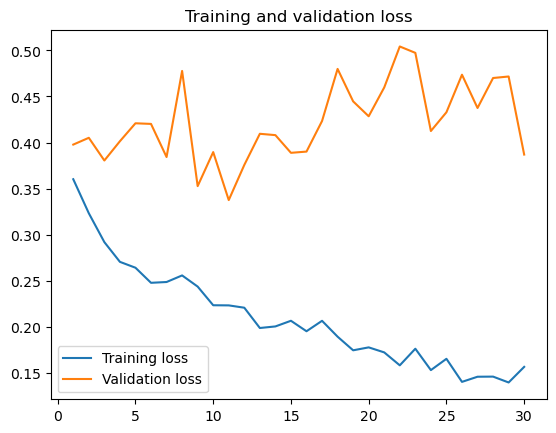

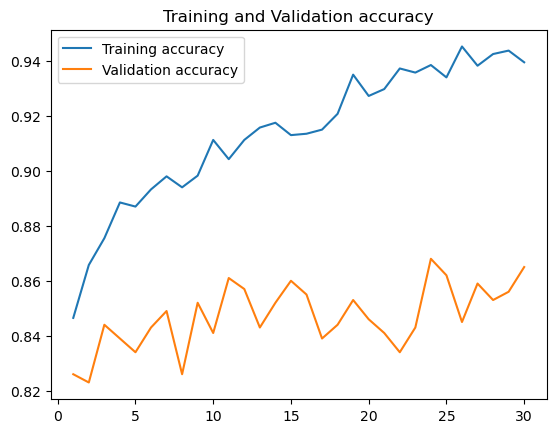

```python
# Storing accuracies and losses in variables
accuracy = history.history["accuracy"]
val_accuracy = history.history["val_accuracy"]
loss = history.history["loss"]
val_loss = history.history["val_loss"]
epochs = range(1,len(accuracy)+1)
# Plotting losses
plt.plot(epochs,loss,label="Training loss")
plt.plot(epochs,val_loss,label="Validation loss")
plt.title("Training and validation loss")
plt.legend()
plt.figure()
# Plotting accuracies
plt.plot(epochs,accuracy,label="Training accuracy")
plt.plot(epochs, val_accuracy,label="Validation accuracy")
plt.title("Training and Validation accuracy")
plt.legend()
```

Evaluating on testing data :

```python
model.evaluate(Test)
```

```
32/32 ━━━━━━━━━━━━━━━━━━━━ 4s 123ms/step - accuracy: 0.8741 - loss: 0.3932
```

```
[0.45582056045532227, 0.8629999756813049]
```

After incresaing the training sample size to 2000, we got a higher accuracy of **87.4%**

**Q-3 Now change your training sample so that you achieve better performance than those from Steps 1 and 2. This sample size may be larger, or smaller than those in the previous steps. The objective is to find the ideal training sample size to get best predictionresults.**

Increasing the training sample size:

```python
make_subset("Training_3",start_index=0,end_index=2500)
make_subset("Validation_3",start_index = 2500, end_index = 3000)
make_subset("Test_3",start_index = 3000,end_index = 3500)
```

Making new training, validation and testing sets :

```python
Train = id("/Users/devmarwah/Desktop/dogs-vs-cats/Small/Training_3",image_size=(180,180),batch_size=32)
Validation = id("/Users/devmarwah/Desktop/dogs-vs-cats/Small/Validation_3",image_size=(180,180),batch_size=32)
Test = id("/Users/devmarwah/Desktop/dogs-vs-cats/Small/Test_3",image_size=(180,180),batch_size=32)
```

```
Found 5000 files belonging to 2 classes.
Found 1000 files belonging to 2 classes.
Found 1000 files belonging to 2 classes.
```

Fitting model on these new sets :

```python
training = model.fit(Train,
                   epochs=30,
                   validation_data = Validation)
```

```
157/157 ━━━━━━━━━━━━━━━━━━━━ 79s 505ms/step - accuracy: 0.9279 - loss: 0.1911 - val_accuracy: 0.8380 - val_loss: 0.4499
157/157 ━━━━━━━━━━━━━━━━━━━━ 87s 550ms/step - accuracy: 0.9227 - loss: 0.1956 - val_accuracy: 0.8630 - val_loss: 0.3506
157/157 ━━━━━━━━━━━━━━━━━━━━ 91s 576ms/step - accuracy: 0.9312 - loss: 0.1770 - val_accuracy: 0.8510 - val_loss: 0.4737
157/157 ━━━━━━━━━━━━━━━━━━━━ 89s 567ms/step - accuracy: 0.9161 - loss: 0.2142 - val_accuracy: 0.8800 - val_loss: 0.3441
157/157 ━━━━━━━━━━━━━━━━━━━━ 92s 583ms/step - accuracy: 0.9344 - loss: 0.1668 - val_accuracy: 0.8790 - val_loss: 0.3679
157/157 ━━━━━━━━━━━━━━━━━━━━ 93s 591ms/step - accuracy: 0.9323 - loss: 0.1765 - val_accuracy: 0.8750 - val_loss: 0.3254
157/157 ━━━━━━━━━━━━━━━━━━━━ 92s 587ms/step - accuracy: 0.9438 - loss: 0.1462 - val_accuracy: 0.8550 - val_loss: 0.4201
157/157 ━━━━━━━━━━━━━━━━━━━━ 92s 582ms/step - accuracy: 0.9417 - loss: 0.1483 - val_accuracy: 0.8660 - val_loss: 0.3891
157/157 ━━━━━━━━━━━━━━━━━━━━ 92s 584ms/step - accuracy: 0.9433 - loss: 0.1417 - val_accuracy: 0.8590 - val_loss: 0.3701
157/157 ━━━━━━━━━━━━━━━━━━━━ 94s 598ms/step - accuracy: 0.9410 - loss: 0.1573 - val_accuracy: 0.8610 - val_loss: 0.3520
157/157 ━━━━━━━━━━━━━━━━━━━━ 91s 578ms/step - accuracy: 0.9441 - loss: 0.1486 - val_accuracy: 0.8570 - val_loss: 0.4176
157/157 ━━━━━━━━━━━━━━━━━━━━ 90s 575ms/step - accuracy: 0.9425 - loss: 0.1469 - val_accuracy: 0.8620 - val_loss: 0.3855
157/157 ━━━━━━━━━━━━━━━━━━━━ 88s 557ms/step - accuracy: 0.9375 - loss: 0.1569 - val_accuracy: 0.8610 - val_loss: 0.3637
157/157 ━━━━━━━━━━━━━━━━━━━━ 86s 545ms/step - accuracy: 0.9416 - loss: 0.1438 - val_accuracy: 0.8780 - val_loss: 0.3996
157/157 ━━━━━━━━━━━━━━━━━━━━ 86s 548ms/step - accuracy: 0.9432 - loss: 0.1440 - val_accuracy: 0.8520 - val_loss: 0.5148
157/157 ━━━━━━━━━━━━━━━━━━━━ 86s 546ms/step - accuracy: 0.9380 - loss: 0.1499 - val_accuracy: 0.8590 - val_loss: 0.3536
157/157 ━━━━━━━━━━━━━━━━━━━━ 86s 547ms/step - accuracy: 0.9337 - loss: 0.1541 - val_accuracy: 0.8760 - val_loss: 0.3407
157/157 ━━━━━━━━━━━━━━━━━━━━ 86s 550ms/step - accuracy: 0.9510 - loss: 0.1162 - val_accuracy: 0.8690 - val_loss: 0.4527
157/157 ━━━━━━━━━━━━━━━━━━━━ 88s 557ms/step - accuracy: 0.9555 - loss: 0.1245 - val_accuracy: 0.8880 - val_loss: 0.3403
157/157 ━━━━━━━━━━━━━━━━━━━━ 89s 564ms/step - accuracy: 0.9396 - loss: 0.1477 - val_accuracy: 0.8760 - val_loss: 0.4279
157/157 ━━━━━━━━━━━━━━━━━━━━ 89s 564ms/step - accuracy: 0.9492 - loss: 0.1286 - val_accuracy: 0.8370 - val_loss: 0.5285
157/157 ━━━━━━━━━━━━━━━━━━━━ 88s 559ms/step - accuracy: 0.9423 - loss: 0.1436 - val_accuracy: 0.8770 - val_loss: 0.3757
157/157 ━━━━━━━━━━━━━━━━━━━━ 89s 564ms/step - accuracy: 0.9572 - loss: 0.1142 - val_accuracy: 0.8680 - val_loss: 0.4292
157/157 ━━━━━━━━━━━━━━━━━━━━ 91s 581ms/step - accuracy: 0.9416 - loss: 0.1428 - val_accuracy: 0.8740 - val_loss: 0.3922
157/157 ━━━━━━━━━━━━━━━━━━━━ 90s 572ms/step - accuracy: 0.9603 - loss: 0.1029 - val_accuracy: 0.8760 - val_loss: 0.4285
157/157 ━━━━━━━━━━━━━━━━━━━━ 87s 551ms/step - accuracy: 0.9466 - loss: 0.1287 - val_accuracy: 0.8570 - val_loss: 0.4508
157/157 ━━━━━━━━━━━━━━━━━━━━ 87s 552ms/step - accuracy: 0.9482 - loss: 0.1274 - val_accuracy: 0.8720 - val_loss: 0.4341
157/157 ━━━━━━━━━━━━━━━━━━━━ 88s 560ms/step - accuracy: 0.9542 - loss: 0.1264 - val_accuracy: 0.8810 - val_loss: 0.4005
157/157 ━━━━━━━━━━━━━━━━━━━━ 88s 563ms/step - accuracy: 0.9577 - loss: 0.1056 - val_accuracy: 0.8620 - val_loss: 0.4392
157/157 ━━━━━━━━━━━━━━━━━━━━ 89s 567ms/step - accuracy: 0.9488 - loss: 0.1252 - val_accuracy: 0.8680 - val_loss: 0.4602
```

Plotting losses and accuracies:

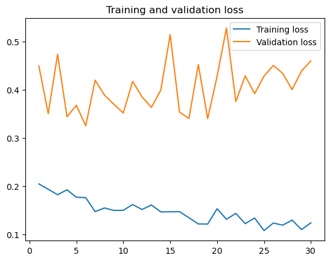

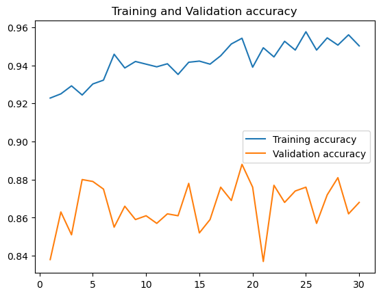

```python
# Storing accuracies and losses in variables
accuracy = training.history["accuracy"]
val_accuracy = training.history["val_accuracy"]
loss = training.history["loss"]
val_loss = training.history["val_loss"]
epochs = range(1,len(accuracy)+1)
# Plotting losses
plt.plot(epochs,loss,label="Training loss")
plt.plot(epochs,val_loss,label="Validation loss")
plt.title("Training and validation loss")
plt.legend()
plt.figure()
# Plotting accuracies
plt.plot(epochs,accuracy,label="Training accuracy")
plt.plot(epochs, val_accuracy,label="Validation accuracy")
plt.title("Training and Validation accuracy")
plt.legend()
```

Evaluating on testing data :

```python
model.evaluate(Test)
```

```
32/32 ━━━━━━━━━━━━━━━━━━━━ 4s 120ms/step - accuracy: 0.8970 - loss: 0.3648
```

```
[0.3699556887149811, 0.8960000276565552]
```

**Q-4 Repeat Steps 1-3, but now using a pretrained network. The sample sizes you use in Steps 2 and 3 for the pretrained network may be the same or different from those using the network where you trained from scratch. Again, use any and all optimization techniques to get best performance.**

Instantiating VGG16 :

```python
conv_base = keras.applications.vgg16.VGG16(
    weights="imagenet",
    include_top=False)
conv_base.trainable = False
```

Constructing a model with data augmentation and pre trained model :

```python
data_augmentation = keras.Sequential(
    [
        layers.RandomFlip("horizontal"),
        layers.RandomRotation(0.1),
        layers.RandomZoom(0.2),
] )
inputs = keras.Input(shape=(180, 180, 3))
x = data_augmentation(inputs)
x = keras.applications.vgg16.preprocess_input(x)
x = conv_base(x)
x = layers.Flatten()(x)
x = layers.Dense(256)(x)
x = layers.Dropout(0.5)(x)
outputs = layers.Dense(1, activation="sigmoid")(x)
model = keras.Model(inputs, outputs)
model.compile(loss="binary_crossentropy",
              optimizer="rmsprop",
              metrics=["accuracy"])
model.summary()
```

```
Model: "functional_9"
```

```
┏━━━━━━━━━━━━━━━━━━━━━┳━━━━━━━━━━━━━━━━━━━┳━━━━━━━━━━━━┳━━━━━━━━━━━━━━━━━━━┓
┃ Layer (type)        ┃ Output Shape      ┃    Param # ┃ Connected to      ┃
┡━━━━━━━━━━━━━━━━━━━━━╇━━━━━━━━━━━━━━━━━━━╇━━━━━━━━━━━━╇━━━━━━━━━━━━━━━━━━━┩
│ input_layer_8       │ (None, 180, 180,  │          0 │ -                 │
│ (InputLayer)        │ 3)                │            │                   │
├─────────────────────┼───────────────────┼────────────┼───────────────────┤
│ sequential_2        │ (None, 180, 180,  │          0 │ input_layer_8[0]… │
│ (Sequential)        │ 3)                │            │                   │
├─────────────────────┼───────────────────┼────────────┼───────────────────┤
│ get_item_3          │ (None, 180, 180)  │          0 │ sequential_2[0][… │
│ (GetItem)           │                   │            │                   │
├─────────────────────┼───────────────────┼────────────┼───────────────────┤
│ get_item_4          │ (None, 180, 180)  │          0 │ sequential_2[0][… │
│ (GetItem)           │                   │            │                   │
├─────────────────────┼───────────────────┼────────────┼───────────────────┤
│ get_item_5          │ (None, 180, 180)  │          0 │ sequential_2[0][… │
│ (GetItem)           │                   │            │                   │
├─────────────────────┼───────────────────┼────────────┼───────────────────┤
│ stack_1 (Stack)     │ (None, 180, 180,  │          0 │ get_item_3[0][0], │
│                     │ 3)                │            │ get_item_4[0][0], │
│                     │                   │            │ get_item_5[0][0]  │
├─────────────────────┼───────────────────┼────────────┼───────────────────┤
│ add_1 (Add)         │ (None, 180, 180,  │          0 │ stack_1[0][0]     │
│                     │ 3)                │            │                   │
├─────────────────────┼───────────────────┼────────────┼───────────────────┤
│ vgg16 (Functional)  │ (None, 5, 5, 512) │ 14,714,688 │ add_1[0][0]       │
├─────────────────────┼───────────────────┼────────────┼───────────────────┤
│ flatten_3 (Flatten) │ (None, 12800)     │          0 │ vgg16[1][0]       │
├─────────────────────┼───────────────────┼────────────┼───────────────────┤
│ dense_4 (Dense)     │ (None, 256)       │  3,277,056 │ flatten_3[0][0]   │
├─────────────────────┼───────────────────┼────────────┼───────────────────┤
│ dropout_2 (Dropout) │ (None, 256)       │          0 │ dense_4[0][0]     │
├─────────────────────┼───────────────────┼────────────┼───────────────────┤
│ dense_5 (Dense)     │ (None, 1)         │        257 │ dropout_2[0][0]   │
└─────────────────────┴───────────────────┴────────────┴───────────────────┘
```

```
 Total params: 17,992,001 (68.63 MB)
```

```
 Trainable params: 3,277,313 (12.50 MB)
```

```
 Non-trainable params: 14,714,688 (56.13 MB)
```

**Using Step - 1 samples**

```python
Train = id("/Users/devmarwah/Desktop/dogs-vs-cats/Small/Training",image_size=(180,180),batch_size=32)
Validation = id("/Users/devmarwah/Desktop/dogs-vs-cats/Small/Validation",image_size=(180,180),batch_size=32)
Test = id("/Users/devmarwah/Desktop/dogs-vs-cats/Small/Test",image_size=(180,180),batch_size=32)
```

```
Found 2000 files belonging to 2 classes.
Found 1000 files belonging to 2 classes.
Found 1000 files belonging to 2 classes.
```

Fitting the model :

```python
training = model.fit(Train,
                    epochs=10,
                    validation_data = Validation)
```

```
63/63 ━━━━━━━━━━━━━━━━━━━━ 260s 4s/step - accuracy: 0.9667 - loss: 4.4905 - val_accuracy: 0.9700 - val_loss: 4.2847
63/63 ━━━━━━━━━━━━━━━━━━━━ 267s 4s/step - accuracy: 0.9703 - loss: 2.9787 - val_accuracy: 0.9760 - val_loss: 3.3311
63/63 ━━━━━━━━━━━━━━━━━━━━ 271s 4s/step - accuracy: 0.9606 - loss: 5.4455 - val_accuracy: 0.9760 - val_loss: 3.5408
63/63 ━━━━━━━━━━━━━━━━━━━━ 289s 5s/step - accuracy: 0.9728 - loss: 3.3661 - val_accuracy: 0.9790 - val_loss: 3.3741
63/63 ━━━━━━━━━━━━━━━━━━━━ 271s 4s/step - accuracy: 0.9702 - loss: 4.1492 - val_accuracy: 0.9820 - val_loss: 2.4781
63/63 ━━━━━━━━━━━━━━━━━━━━ 268s 4s/step - accuracy: 0.9688 - loss: 4.3706 - val_accuracy: 0.9820 - val_loss: 2.6704
63/63 ━━━━━━━━━━━━━━━━━━━━ 270s 4s/step - accuracy: 0.9836 - loss: 1.1871 - val_accuracy: 0.9780 - val_loss: 3.8882
63/63 ━━━━━━━━━━━━━━━━━━━━ 259s 4s/step - accuracy: 0.9789 - loss: 2.8218 - val_accuracy: 0.9760 - val_loss: 3.4797
63/63 ━━━━━━━━━━━━━━━━━━━━ 283s 5s/step - accuracy: 0.9777 - loss: 1.9090 - val_accuracy: 0.9790 - val_loss: 2.5988
63/63 ━━━━━━━━━━━━━━━━━━━━ 285s 5s/step - accuracy: 0.9800 - loss: 2.2125 - val_accuracy: 0.9780 - val_loss: 3.5314
```

Plotting accuracies and losses :

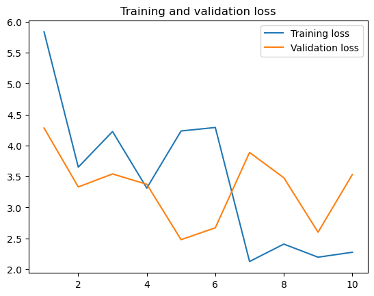

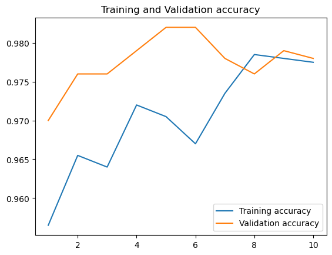

```python
# Storing accuracies and losses in variables
accuracy = training.history["accuracy"]
val_accuracy = training.history["val_accuracy"]
loss = training.history["loss"]
val_loss = training.history["val_loss"]
epochs = range(1,len(accuracy)+1)
# Plotting losses
plt.plot(epochs,loss,label="Training loss")
plt.plot(epochs,val_loss,label="Validation loss")
plt.title("Training and validation loss")
plt.legend()
plt.figure()
# Plotting accuracies
plt.plot(epochs,accuracy,label="Training accuracy")
plt.plot(epochs, val_accuracy,label="Validation accuracy")
plt.title("Training and Validation accuracy")
plt.legend()
```

Evaluating our model :

```python
model.evaluate(Test)
```

```
32/32 ━━━━━━━━━━━━━━━━━━━━ 73s 2s/step - accuracy: 0.9724 - loss: 4.6065
```

```
[4.240532398223877, 0.9710000157356262]
```

**Using Step - 2 samples**

```python
Train = id("/Users/devmarwah/Desktop/dogs-vs-cats/Small/Training_2",image_size=(180,180),batch_size=32)
Validation = id("/Users/devmarwah/Desktop/dogs-vs-cats/Small/Validation_2",image_size=(180,180),batch_size=32)
Test = id("/Users/devmarwah/Desktop/dogs-vs-cats/Small/Test_2",image_size=(180,180),batch_size=32)
```

```
Found 4000 files belonging to 2 classes.
Found 1000 files belonging to 2 classes.
Found 1000 files belonging to 2 classes.
```

Fitting the model :

```python
training = model.fit(Train,
                    epochs=10,
                    validation_data = Validation)
```

[output not shown]

Plotting accuracies and losses :

```python
# Storing accuracies and losses in variables
accuracy = training.history["accuracy"]
val_accuracy = training.history["val_accuracy"]
loss = training.history["loss"]
val_loss = training.history["val_loss"]
epochs = range(1,len(accuracy)+1)
# Plotting losses
plt.plot(epochs,loss,label="Training loss")
plt.plot(epochs,val_loss,label="Validation loss")
plt.title("Training and validation loss")
plt.legend()
plt.figure()
# Plotting accuracies
plt.plot(epochs,accuracy,label="Training accuracy")
plt.plot(epochs, val_accuracy,label="Validation accuracy")
plt.title("Training and Validation accuracy")
plt.legend()
```

[output not shown]

Evaluating the model :

```python
model.evaluate(Test)
```

[output not shown]

**Using Step-3 samples**

```python
Train = id("/Users/devmarwah/Desktop/dogs-vs-cats/Small/Training_3",image_size=(180,180),batch_size=32)
Validation = id("/Users/devmarwah/Desktop/dogs-vs-cats/Small/Validation_3",image_size=(180,180),batch_size=32)
Test = id("/Users/devmarwah/Desktop/dogs-vs-cats/Small/Test_3",image_size=(180,180),batch_size=32)
```

[output not shown]

Fine tuning the model this time to get even better results :

```python
conv_base.trainable = True
for layer in conv_base.layers[:-4]:
    layers.trainable = False
```

Compiling the model again to reduce learning rate:

```python
model.compile(loss="binary_crossentropy",
              optimizer=keras.optimizers.RMSprop(learning_rate=1e-5),
              metrics=["accuracy"])
```

Fitting the model:

```python
training = model.fit(Train,
                    epochs=10,
                    validation_data=Validation)
```

[output not shown]

Plotting accuracies and losses:

```python
# Storing accuracies and losses in variables
accuracy = training.history["accuracy"]
val_accuracy = training.history["val_accuracy"]
loss = training.history["loss"]
val_loss = training.history["val_loss"]
epochs = range(1,len(accuracy)+1)
# Plotting losses
plt.plot(epochs,loss,label="Training loss")
plt.plot(epochs,val_loss,label="Validation loss")
plt.title("Training and validation loss")
plt.legend()
plt.figure()
# Plotting accuracies
plt.plot(epochs,accuracy,label="Training accuracy")
plt.plot(epochs, val_accuracy,label="Validation accuracy")
plt.title("Training and Validation accuracy")
plt.legend()
```

[output not shown]

Evaluating the model:

```python
model.evaluate(Test)
```

[output not shown]